# Multilevel & Predictive Model

Ha Thuong Tran

2024-02-05

```r
# load the packages
library(here)
library(tidyverse)
library(caret)
library(ranger)
library(e1071)
library(tidylog)
library(dataedu)
library(nnet)
```

# Import data

```r
here()
```

```
## [1] "C:/Users/efuma/Downloads/UDE/DS_Education/Multilevel & Predictive Model"
```

```r
data <- read_delim("data.csv", show_col_types = FALSE)

head(data)
```

```
## # A tibble: 6 × 37
##   `Marital status` `Application mode` `Application order` Course
##              <dbl>              <dbl>               <dbl>  <dbl>
## 1                1                 17                   5    171
## 2                1                 15                   1   9254
## 3                1                  1                   5   9070
## 4                1                 17                   2   9773
## 5                2                 39                   1   8014
## 6                2                 39                   1   9991
## # ℹ 33 more variables: `Daytime/evening attendance\t` <dbl>,
## #   `Previous qualification` <dbl>, `Previous qualification (grade)` <dbl>,
## #   Nacionality <dbl>, `Mother's qualification` <dbl>,
## #   `Father's qualification` <dbl>, `Mother's occupation` <dbl>,
## #   `Father's occupation` <dbl>, `Admission grade` <dbl>, Displaced <dbl>,
## #   `Educational special needs` <dbl>, Debtor <dbl>,
## #   `Tuition fees up to date` <dbl>, Gender <dbl>, …
```

```r
colnames(data)
```

```
##  [1] "Marital status"
##  [2] "Application mode"
##  [3] "Application order"
##  [4] "Course"
##  [5] "Daytime/evening attendance\t"
##  [6] "Previous qualification"
##  [7] "Previous qualification (grade)"
##  [8] "Nacionality"
##  [9] "Mother's qualification"
## [10] "Father's qualification"
## [11] "Mother's occupation"
## [12] "Father's occupation"
## [13] "Admission grade"
## [14] "Displaced"
## [15] "Educational special needs"
```

[output cut: 22 more lines]

# Research question: Which individual factors affect whether the students drop out or not?

** Select variables**

Here we have almost 40 variables, a lot of them can be used as predictors for academic success and dropout rates. These predictors can be put into different categories, one being the individual predictors, which provide information on academic path, demographics, and social-economic situations of the students, another being the macroeconomic factors, which are not specific to individual students or programs but may still have an impact on student outcomes. Here I’d focus on the effect of the factors pertaining to the individuals on whether or not the students dropped out.

```r
data <- data %>%
  select("Marital status",
         "Course",
         "Previous qualification",
         "Previous qualification (grade)",
         "Nacionality",
         "Mother's qualification",
         "Father's qualification",
         "Mother's occupation",
         "Father's occupation",
         "Admission grade",
         "Displaced",
         "Educational special needs",
         "Debtor",
         "Tuition fees up to date",
         "Gender",
         "Scholarship holder",
         "Age at enrollment",
         "International",
         "Target"
         )
```

```
## select: dropped 18 variables (Application mode, Application order, Daytime/evening attendance    , Curricular units 1st sem (credited), Curricular units 1st sem (enrolled), …)
```

```r
colnames(data)
```

```
##  [1] "Marital status"                 "Course"
##  [3] "Previous qualification"         "Previous qualification (grade)"
##  [5] "Nacionality"                    "Mother's qualification"
##  [7] "Father's qualification"         "Mother's occupation"
##  [9] "Father's occupation"            "Admission grade"
## [11] "Displaced"                      "Educational special needs"
## [13] "Debtor"                         "Tuition fees up to date"
## [15] "Gender"                         "Scholarship holder"
## [17] "Age at enrollment"              "International"
## [19] "Target"
```

# Methods

## Random forest

Random forest is applied to approach the research question.

**Process data**

According to the provider of the dataset, no row contains missing values, so we don’t need to omit those.

Now we will check if there are variables with no variability.

```r
nearZeroVar(data, saveMetrics = TRUE)
```

```
##                                 freqRatio percentUnique zeroVar   nzv
## Marital status                  10.340369    0.13562387   FALSE FALSE
## Course                           2.015789    0.38426763   FALSE FALSE
## Previous qualification          16.972603    0.38426763   FALSE FALSE
## Previous qualification (grade)   1.309333    2.28300181   FALSE FALSE
## Nacionality                    113.526316    0.47468354   FALSE  TRUE
## Mother's qualification           1.059465    0.65551537   FALSE FALSE
## Father's qualification           1.248967    0.76853526   FALSE FALSE
## Mother's occupation              1.930233    0.72332731   FALSE FALSE
## Father's occupation              1.516517    1.03978300   FALSE FALSE
## Admission grade                  1.058824   14.01446655   FALSE FALSE
## Displaced                        1.214214    0.04520796   FALSE FALSE
## Educational special needs       85.745098    0.04520796   FALSE  TRUE
## Debtor                           7.795229    0.04520796   FALSE FALSE
## Tuition fees up to date          7.378788    0.04520796   FALSE FALSE
## Gender                           1.843188    0.04520796   FALSE FALSE
## Scholarship holder               3.025478    0.04520796   FALSE FALSE
## Age at enrollment                1.137212    1.03978300   FALSE FALSE
## International                   39.218182    0.04520796   FALSE  TRUE
## Target                           1.554539    0.06781193   FALSE FALSE
```

We can see from the zeroVar column that all of our variables have variability.

We check the number of rows in the dataset.

```r
nrow(data)
```

```
## [1] 4424
```

We also need to ensure that the character variables are converted into factors.

```r
# converting the text (character) variables in our dataset into factors
data <-
    data %>%
    mutate_if(is.character, as.factor)
```

```
## mutate_if: converted 'Target' from character to factor (0 new NA)
```

**Prepare train and test datasets**

```r
set.seed(2024)

## 80% of the original dataset is used for training the model
trainIndex <- createDataPartition(data$Target, p = .8, list = FALSE, times = 1)

data <- data %>% mutate(temp_id = 1:4424)
```

```
## mutate: new variable 'temp_id' (integer) with 4,424 unique values and 0% NA
```

```r
# we filter our dataset so that we get only the
# rows indicated by our "trainIndex" vector
data_train <-
    data %>%
    filter(temp_id %in% trainIndex)
```

```
## filter: removed 883 rows (20%), 3,541 rows remaining
```

```r
# we filter our dataset in a different way so that we get only the rows
# NOT in our "trainIndex" vector
# adding the ! before the temp_id variable achieves the opposite of
# what we did in the line of code above

data_test <-
    data %>%
    filter(!temp_id %in% trainIndex)
```

```
## filter: removed 3,541 rows (80%), 883 rows remaining
```

```r
# We delete the temp_id variable from (1) the original data,
# (2) the portion of the original data we marked as training, and
# (3) the portion of the original data we marked as testing,
# as we no longer need that variable

data <-
    data %>%
    select(-temp_id)
```

```
## select: dropped one variable (temp_id)
```

```r
data_train <-
    data_train %>%
    select(-temp_id)
```

```
## select: dropped one variable (temp_id)
```

```r
data_test <-
    data_test %>%
    select(-temp_id)
```

```
## select: dropped one variable (temp_id)
```

**Run the model**

```r
# setting a seed for reproducibility
set.seed(2020)

# we run the model here
rf_fit <- train(Target ~ .,
                data = data_train,
                method = "ranger")

# here, we get a summary of the model we just built
rf_fit
```

```
## Random Forest
##
## 3541 samples
##   18 predictor
##    3 classes: 'Dropout', 'Enrolled', 'Graduate'
##
## No pre-processing
## Resampling: Bootstrapped (25 reps)
## Summary of sample sizes: 3541, 3541, 3541, 3541, 3541, 3541, ...
## Resampling results across tuning parameters:
##
##   mtry  splitrule   Accuracy   Kappa
##    2    gini        0.6264747  0.3211434
##    2    extratrees  0.6200636  0.2986325
##   10    gini        0.6095637  0.3277518
##   10    extratrees  0.6022002  0.3113624
##   18    gini        0.6031468  0.3212443
##   18    extratrees  0.5981969  0.3086820
##
## Tuning parameter 'min.node.size' was held constant at a value of 1
## Accuracy was used to select the optimal model using the largest value.
## The final values used for the model were mtry = 2, splitrule = gini
##  and min.node.size = 1.
```

Apparently the model with the value of the mtry tuning parameter equal to 2 explains the data best, the splitrule being “gini” and min.node.size held at a value of 1.

**Fine-tune the model**

```r
tune_grid <- expand.grid(
  mtry = c(2, 10, 18),
  splitrule = c("gini", "extratrees"),
  min.node.size = c(1, 5, 10, 15, 20)
)

rf_fit2 <-
    train(Target ~ .,
          data = data_train,
          method = "ranger",
          tuneGrid = tune_grid)

rf_fit2
```

```
## Random Forest
##
## 3541 samples
##   18 predictor
##    3 classes: 'Dropout', 'Enrolled', 'Graduate'
##
## No pre-processing
## Resampling: Bootstrapped (25 reps)
## Summary of sample sizes: 3541, 3541, 3541, 3541, 3541, 3541, ...
## Resampling results across tuning parameters:
##
##   mtry  splitrule   min.node.size  Accuracy   Kappa
##    2    gini         1             0.6239726  0.3176087
##    2    gini         5             0.6239363  0.3173469
##    2    gini        10             0.6250194  0.3195301
```

[output cut: 31 more lines]

We have a new best model but the improvement was not too considerable. Now we want to select only the final model used.

```r
rf_fit2$finalModel
```

```
## Ranger result
##
## Call:
##  ranger::ranger(dependent.variable.name = ".outcome", data = x,      mtry = min(param$mtry, ncol(x)), min.node.size = param$min.node.size,      splitrule = as.character(param$splitrule), write.forest = TRUE,      probability = classProbs, ...)
##
## Type:                             Classification
## Number of trees:                  500
## Sample size:                      3541
## Number of independent variables:  18
## Mtry:                             2
## Target node size:                 10
## Variable importance mode:         none
## Splitrule:                        gini
## OOB prediction error:             37.02 %
```

The reported OOB error of 37.02% suggests that, on average, the model is expected to make correct predictions about 62.98% of the time on new data.

**Examine the accuracy on the test data set**

```r
# setting a seed for reproducibility
set.seed(2020)

# Create a new object for the testing data including predicted values
data_test_augmented <-
    data_test %>%
    mutate(pred = predict(rf_fit2, data_test),
           obs = Target)
```

```
## mutate: new variable 'pred' (factor) with 3 unique values and 0% NA
```

```
##         new variable 'obs' (factor) with 3 unique values and 0% NA
```

```r
# Transform this new object into a data frame
defaultSummary(as.data.frame(data_test_augmented))
```

```
##  Accuracy     Kappa
## 0.6319366 0.3319467
```

The accuracy for the test data is even a bit higher than for the training data, which suggests the model is able to handle new data.

**Variable importance**

```r
# setting a seed for reproducibility
set.seed(2020)

# Specify the same model as earlier in the chapter (rf_fit2) with the addition of the variable importance metric
rf_fit2_imp <-
    train(
        Target ~ .,
        data = data_train,
        method = "ranger",
        tuneGrid = tune_grid,
        importance = "permutation"
    )

# Extract the variable importance from this new model
varImp(rf_fit2_imp)
```

```
## ranger variable importance
##
##                                    Overall
## `Tuition fees up to date`        100.00000
## `Age at enrollment`               60.09345
## `Scholarship holder`              35.46457
## Course                            31.46446
## Gender                            25.27741
## Debtor                            24.80102
## `Previous qualification (grade)`  20.48499
## `Admission grade`                 16.84621
## `Mother's occupation`             12.15543
## `Father's occupation`              8.93737
## `Mother's qualification`           7.45420
## `Previous qualification`           6.37649
## Displaced                          5.32866
## `Marital status`                   5.20585
## `Father's qualification`           4.48030
## International                      0.08512
## `Educational special needs`        0.08220
## Nacionality                        0.00000
```

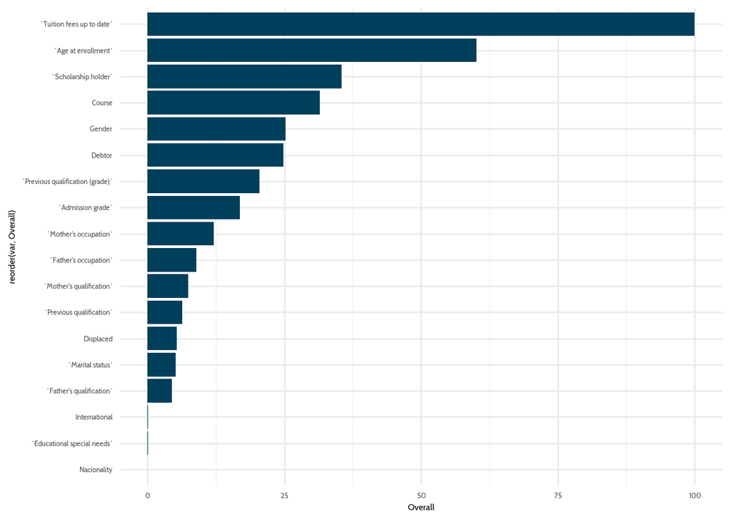

```r
varImp(rf_fit2_imp) %>%
    pluck(1) %>%
    rownames_to_column("var") %>%
    ggplot(aes(x = reorder(var, Overall), y = Overall)) +
    geom_col(fill = dataedu_colors("darkblue")) +
    coord_flip() +
    theme_dataedu()
```

Here we could see the most important factors contributing to the model, but we can’t see exactly how the predictors influence the likelihood of a student dropping out. We know that “tuition fees up to date” is important, but we don’t know if that is a predictor for a student being enrolled, already graduating, or dropping out (though we can certainly take a guess).

## Multilevel Multinomial Logistic Regression Model

We take a closer look at the impact of the predictors with a logistic regression model. We also want to pass “Course” as an additional argument for the group.

```r
# Fit a multilevel multinomial logistic regression model
multilevel_model <- multinom(Target ~ . + (1|Course), data = data)
# Extract coefficients
coefficients <- coef(multilevel_model)
print(coefficients)
```

```
##          (Intercept) `Marital status`       Course `Previous qualification`
## Enrolled   -0.349697       0.15904705 2.213257e-05             0.0061343495
## Graduate   -1.986764       0.09148277 3.385821e-05            -0.0001265298
##          `Previous qualification (grade)` Nacionality `Mother's qualification`
## Enrolled                     -0.009577337 -0.01870707             -0.010557092
## Graduate                     -0.002673216 -0.03442624             -0.005500874
##          `Father's qualification` `Mother's occupation` `Father's occupation`
## Enrolled              0.002478692           0.009199224          -0.002242024
## Graduate              0.002309754           0.005962295          -0.002556582
##          `Admission grade`   Displaced `Educational special needs`     Debtor
## Enrolled       0.006584619 -0.10014253                  -0.1777543 -0.1464071
## Graduate       0.021964866  0.02411751                  -0.5733783 -0.9258830
##          `Tuition fees up to date`     Gender `Scholarship holder`
## Enrolled                  2.046155 -0.3411130            0.3932069
## Graduate                  3.146849 -0.8494325            1.4520683
##          `Age at enrollment` International 1 | CourseTRUE
## Enrolled         -0.05639605      1.358655      -0.349697
## Graduate         -0.04731742      1.877355      -1.986764
```

```r
# Convert coefficients to odds ratios
odds_ratios <- exp(coefficients)
print(odds_ratios)
```

```
##          (Intercept) `Marital status`   Course `Previous qualification`
## Enrolled   0.7049016         1.172393 1.000022                1.0061532
## Graduate   0.1371384         1.095798 1.000034                0.9998735
##          `Previous qualification (grade)` Nacionality `Mother's qualification`
## Enrolled                        0.9904684   0.9814668                0.9894984
## Graduate                        0.9973304   0.9661596                0.9945142
##          `Father's qualification` `Mother's occupation` `Father's occupation`
## Enrolled                 1.002482              1.009242             0.9977605
## Graduate                 1.002312              1.005980             0.9974467
##          `Admission grade` Displaced `Educational special needs`    Debtor
## Enrolled          1.006606 0.9047085                   0.8371480 0.8638060
## Graduate          1.022208 1.0244107                   0.5636181 0.3961814
##          `Tuition fees up to date`    Gender `Scholarship holder`
## Enrolled                  7.738093 0.7109785             1.481725
## Graduate                 23.262659 0.4276575             4.271941
##          `Age at enrollment` International 1 | CourseTRUE
## Enrolled           0.9451647      3.890958      0.7049016
## Graduate           0.9537846      6.536192      0.1371384
```

What is surprising (and confusing) is that “international”, which was not an important predictor according to the random forest, is the second most important factor here in this logistic regression model. Being an international student is associated with a substantial increase in the odds of being enrolled or graduating compared to being a dropout.

On the contrary, there are a few predictors deemed quite important by the random forest but not by logistic regression, such as “Age at enrollment” and “Course”. This suggests that there might be relationships between “Age at enrollment” / “Course” and our response variable “Target”, which can’t be modelled with linear regression.